# Political Attitudes of the German population based on data from the European Social Survey

Author

Nanmanat Disayakamonpan

This analysis works with the dataset `ESS10_DE_selection` from the European Social Survey (ESS) which is a pan-European research infrastructure providing freely accessible data for academics, policymakers, civil society and the wider public. The ESS tracks the behaviours, attitudes, and beliefs of individuals across European countries.

# 1 Data Overview and Preparation

For this analysis, we will work on the dataset of Political Attitudes of the German population based on data from the European Social Survey (ESS). By now, there are 10 survey waves covering a period from 2002 to 2020. This analysis will only focus on the latest wave and a subset of the questions concerning some political attitudes among German citizens.

In particular, we consider the following items

- **Item Variables and Questions**
  - *freehms*
    - A question asks about opinions on what extent you agree or disagree, with each of the following statements: **“Gay men and lesbians should be free to live their own life as they wish”**, where 1 means you strongly agree and 5 means you strongly disagree.
  - *euftf*
    - A question asks about what number on the scale best describes your position about **“European Union: European unification go further or gone too far”**, where 0 means unification already has gone too far and 10 means unification goes further.
  - *wrclmch*
    - A question asks about **“how worried are you about climate change”**, where 1 means you are not worried at all and 5 means you are extremely worried.
  - *gincdif*
    - A question asks about what extent you agree or disagree with each of the following statements: **“The government should take measures to reduce differences in income levels”**, where 1 means you strongly agree and 5 means you strongly disagree.
  - *imueclt*
    - This observation addresses the question **“Would you say that Germany’s cultural life is generally undermined or enriched by people coming to live here from other countries”**, where 0 means cultural life is undermined and 10 means cultural life is enriched.
  - *lrscale*
    - In politics people sometimes talk of ‘left’ and ‘right’. This question asks about **“where would you place yourself on this scale”**, where 0 means the left and 10 means the right.
  - *impcntr*
    - This observation addresses the question **“To what extent do you think Germany should allow many/few immigrants from poorer countries outside Europe”**, where 1 means Germany should allow many to come and live here, and 4 means Germany should allow none of them.
  - *prtvfde2*
    - Party voted for in last national election 2, Germany as you can see in the table below:

| Value in prtvfde2 | Political Party in Germany |
| --- | --- |
| 1 | Christian Democratic Union/Christian Social Union (CDU/CSU) |
| 2 | Social Democratic Party (SPD) |
| 3 | The Left (Die Linke) |
| 4 | Alliance 90/The Greens (Bündnis 90/Die Grünen) |
| 5 | Free Democratic Party (FDP) |
| 6 | Alternative for Germany (AFD) |

# 2 Data Exploration

## 2.1 Characterising Voters

### 2.1.1 The distribution of left-right scale scores across major political parties in Germany

In this analysis, I aim to explore the political orientation of voters based on the left-right scale (lrscale) and their respective political party affiliations (prtvfde2) in the European Social Survey (ESS) data. I will create a boxplot visualizing the distribution of left-right scale scores across major political parties, using distinct colors for each party to enhance clarity and understanding.

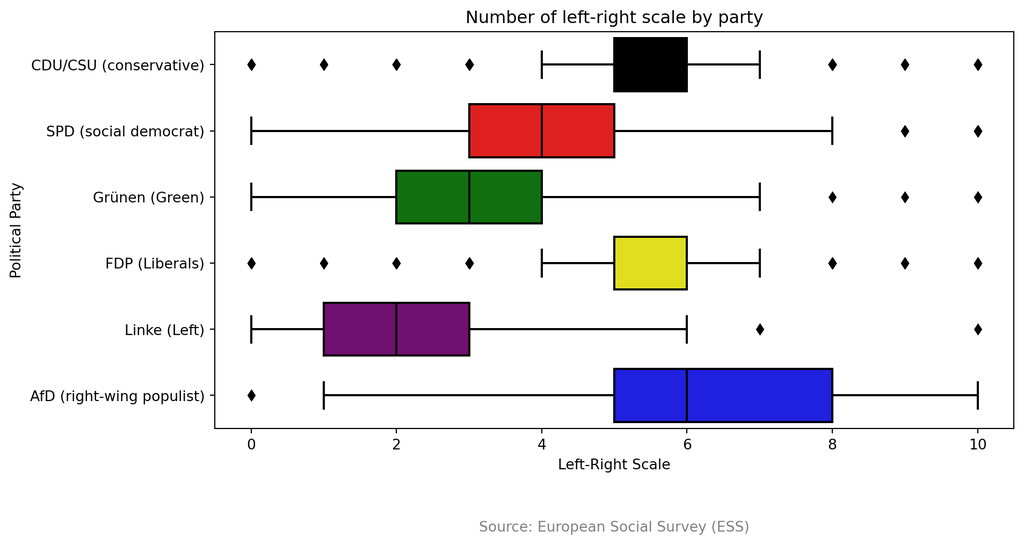

As you can see, the boxplot effectively illustrates the spread and central tendency of left-right scale scores for each political party.

- **Parties on the left side (Die Linke, Grünen, SPD)** with the mean value of 2, 3, 4, respectively, indicate a left-leaning stance.
- **Parties on the right side (CDU/CSU, FDP, AfD)** have higher mean values, indicating a right-leaning or conservative stance.
  - CDU/CSU and FDP show overlap in their boxplots, suggesting some similarity in the left-right scale scores. This aligns with the broader political landscape, where both parties are positioned towards the center-right.
  - The AfD boxplot is distinctly on the right side, further away from the center, with a mean value around 6. This indicates that individuals affiliated with AfD have a more pronounced right-wing populist orientation compared to CDU/CSU and FDP.

### 2.1.2 The distribution of opinions on European Unification across different political parties in Germany

In this exploratory analysis, we aim to understand the distribution of opinions on European unification across different political parties in Germany. The boxplot below illustrates individuals’ positions on the scale of European unification (0 to 10) grouped by the party they voted for in the last national election, providing insights into the varying perspectives within each political affiliation.

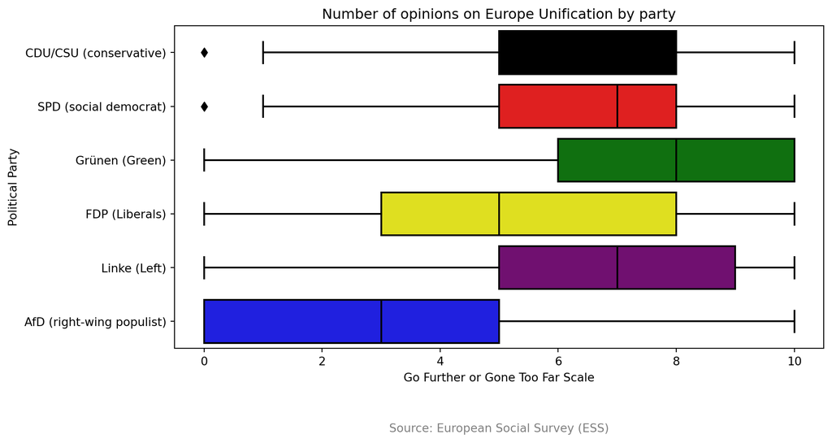

## 2.2 Data Exploration and Visualisation of Two Variables

For this part, I dive into the dataset to explore two important observations —**imueclt**, reflecting views on cultural life, and **impcntr**, gauging attitudes toward immigrants from poorer nations.

**Variable Descriptions**

- **imueclt** This observation addresses the question **“Would you say that Germany’s cultural life is generally undermined or enriched by people coming to live here from other countries”**, where 0 means cultural life is undermined and 10 means cultural life is enriched.

| Value in imueclt | Country’s cultural life undermined or enriched by immigrants |
| --- | --- |
| 0 | Cultural life undermined |
| 1 | 1 |
| 2 | 2 |
| 3 | 3 |
| 4 | 4 |
| 5 | 5 |
| 6 | 6 |
| 7 | 7 |
| 8 | 8 |
| 9 | 9 |
| 10 | Cultural life enriched |

- **impcntr** This observation addresses the question **“To what extent do you think Germany should allow many/few immigrants from poorer countries outside Europe”**, where 1 means Germany should allow many to come and live here, and 4 means Germany should allow none of them.

| Value in impcntr | Allow many/few immigrants from poorer countries outside Europe |
| --- | --- |
| 1 | Allow many to come and live here |
| 2 | Allow some |
| 3 | Allow a few |
| 4 | Allow none |
| 9 | No answer |

### 2.2.1 Scatter Plot Showing Connections between Immigration Perspectives (impcntr) vs. Cultural Attitude (imueclt)

Through a scatter plot, I am investigating the potential relationships between cultural sentiments (‘imueclt’) and opinions on immigration (‘impcntr’), seeking to unravel the dynamics at play within our dataset.

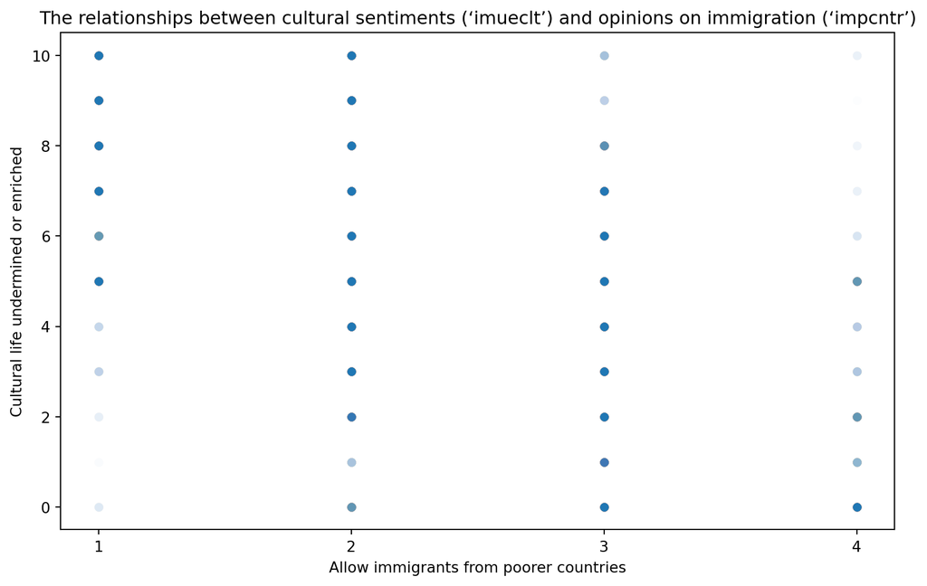

The scatter plot may look uninformative because it seems that the variable ‘impcntr’ is categorical or ordinal, representing different levels of willingness to allow immigrants from poorer countries. However, the scatter plot treats ‘impcntr’ as a continuous variable on the x-axis, which may not accurately represent the underlying nature of the data.

In a scatter plot, points are usually connected along both axes, assuming a continuous relationship between the variables. In this case, where ‘impcntr’ likely represents discrete categories, the points are scattered along the integer values on the x-axis without any meaningful connection between them.

## 2.3 Heatmap Showing Connection between Immigration Perspectives (impcntr) vs. Cultural Attitude (imueclt)

Before diving into a heatmap, I will show you the pivot table that provides a comprehensive overview of the distribution of responses, organized by **the cultural attitudes (imueclt)** and **immigration perspectives (impcntr)** variables. Each cell in the table represents the count of responses corresponding to a specific combination of cultural attitudes and immigration perspectives, offering valuable insights into the patterns within the dataset.

| impcntr imueclt | Allow many | Allow some | Allow a few | Allow none |
| --- | --- | --- | --- | --- |
| Cultural life undermined | 11 | 79 | 206 | 150 |
| 1 | 2 | 34 | 113 | 47 |
| 2 | 8 | 124 | 242 | 78 |
| 3 | 23 | 255 | 303 | 31 |
| 4 | 20 | 260 | 182 | 27 |
| 5 | 158 | 1070 | 485 | 78 |
| 6 | 75 | 478 | 175 | 13 |
| 7 | 264 | 738 | 141 | 7 |
| 8 | 404 | 620 | 84 | 5 |
| 9 | 192 | 160 | 24 | 1 |
| Cultural life enriched | 631 | 325 | 36 | 7 |

This heatmap illustrates the relationship between two categorical variables: **“imueclt”** representing *cultural attitudes* and **“impcntr”** representing *immigration perspectives*. The values in the heatmap represent the frequency or count of responses corresponding to different combinations of cultural attitudes and immigration perspectives.

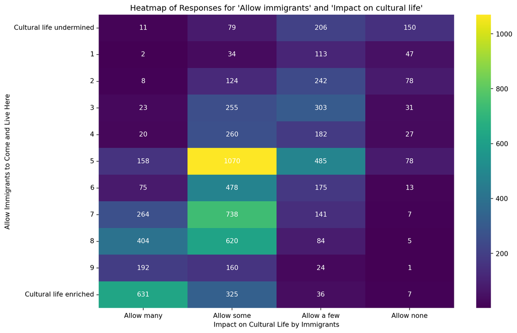

On the contrary, The “Cultural life undermined” row shows a concentration in the **“Allow none”** and **“Allow a few”** columns with 150 and 206 responses, respectively, indicating that *those who perceive cultural life as undermined are less likely to support allowing many immigrants*.

### 2.3.1 Correlation Coefficient of Two Variables between Immigration Perspectives (impcntr) vs. Cultural Attitude (imueclt)

The key point of the correlation coefficient between **immigration perspectives (‘impcntr’)** and **cultural attitudes (‘imueclt’)** is to offer insights into the degree of association between individuals’ perceptions of cultural life and their attitudes toward immigrants from economically disadvantaged countries, as you can see the result below.

```
The Correlation Coefficient is -59.13 %
```

In practical terms, a negative correlation could means that people with positive attitudes toward immigrants are likely to have positive cultural attitudes. Conversely, those with a negative cultural outlook may lean towards restrictive attitudes toward immigrants.

## 2.4 Principle Component Analysis (PCA)

In this analysis, I will do a Principle Component Analysis (PCA) of the political Attitudes in the European Social Survey and focus on the following items.

- **Cultural Life (imueclt):** Is it enriched or undermined by people from other countries?
- **European Unification (euftf):** To what extent should the European Union unify further?
- **Left-Right Scale (lrscale):** Where do individuals place themselves on the political spectrum?
- **Climate Change Concern (wrclmch):** How worried are they about climate change?
- **Income Equality (gincdif):** Do they believe in government measures to reduce income differences?
- **Freedom for All (freehms):** Should gay men and lesbians be free to live their lives as they wish?
- **Immigration Perspectives (impcntr):** How open are they to immigrants from poorer countries?

To have more effective and meaningful visualization, PCA is one of the important parts for this analysis.

### 2.4.1 PCA for Political Attitudes

For this part, I will visually explore political attitudes through a scatter plot of the first and second principal components, where each point represents a respondent colored by their last election’s chosen political party.

To visualize better, I set the following color scheme for each political party.

| Color | Political Party (prtvfde2) in Germany |
| --- | --- |
| black | **CDU/CSU** (Christian Democratic Union/Christian Social Union) |
| red | **SPD** (Social Democratic Party) |
| yellow | **Die Linke** (The Left) |
| green | **Bündnis 90/Die Grünen** (Alliance 90/The Green) |
| purple | **FDP** (Free Democratic Party) |
| blue | **AFD** (Alternative for Germany) |
| grey | **Andere Party** (Other Parties) |

Arrows might reveal how specific attitudes influence the PC1-PC2 space, and the axis labels offer insights into the explained variance of each principal component, giving a peek into the diverse political landscape.

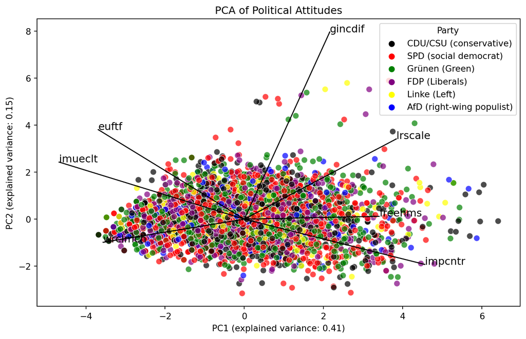

As you can see from the scatter plot, we can conclude that PC1 and PC2 capture different patterns in the political attitudes related to each variable. In the scatter plot, the arrows and labels show the contribution of each variable to PC1 and PC2. The longer the arrow, the stronger the influence.

**PC1 (explained variance: 0.41):**

- PC1 represents a dimension in political attitudes that explains 41% of the total variability in the data. The variables with high positive loadings on PC1 `gincdif`, `lrsclae`, `freehms` and `impcntr`. We can see that `impcntr` contributes strongest positive loadings to this dimension.
- This suggests that PC1 summarizes a substantial portion of the variability present in the political attitude variables. A higher explained variance indicates that PC1 effectively captures patterns and trends in the data

**PC2 (explained variance: 0.15):**

### 2.4.2 Explained Variance

Before diving into the visualization, let’s gauge the landscape of explained variance across principal components. The upcoming plot will provide a roadmap, helping us discern how many principal components might adequately capture the diverse spectrum of respondents’ political attitudes.

[figure not shown]

The values of the cumulative explained variance shown on this plot for PC1 to PC7 provide insights into how much of the total variability in your data is captured by each principal component.

As you can see from the graph, it can be concluded that the first few principal components (PC1 to PC3) capture a substantial portion of the variability in this data. These components represent the dominant patterns or factors that explain respondents’ political attitudes.

### 2.4.3 Variable Loadings

Before we visualize the vectors of the first three principal components, let’s set the stage by qualitatively exploring what PC1, PC2, and PC3 represent in the context of variable loadings.

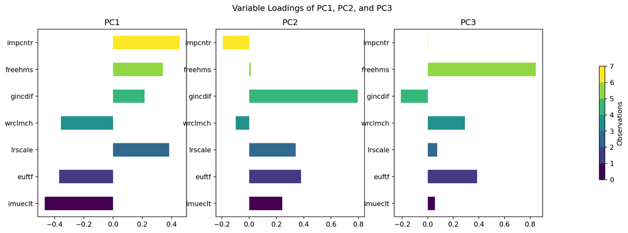

As the bar chart of variable loadings of PC1-PC3, we can conclude **PC1** as follows:

**Positive Correlation**

- More than a half of the variables on PC1 have positive loadings, particularly `impcntr` (0.455), `lrscale` (0.383), `freehms` (0.340), and `gincdif` (0.215).

**Negative Correlation**

- There are also many variable with moderate negative correlations, mainly `imueclt` (-0.467), `euftf` (-0.368), and `wrclmch` (-0.356)

## 2.5 Logistic Regression

Embarking on the journey of predicting voting decisions based on political attitudes, our initial focus lies in discerning patterns that differentiate individuals inclined towards “left” parties (SPD, Die Linke, Die Grünen) from those aligned with “right” parties (CDU/CSU, FDP, AfD).

### 2.5.1 Wrangling and Preprocessing

Before diving into data visualization, I will process the dataset by removing missing values and participants who didn’t vote for specified parties. Then, we’ll create a left_vote variable indicating left or non-left voting. The input matrix, X, representing political attitudes, will be scaled using StandardScaler. Here, let’s proceed to visualize the results.

```python
# 1. Remove all participants with `NaN` values
party_codes = [1, 2, 3, 4, 5, 6]
essdata_cleaned = essdata.dropna(subset=["imueclt", "euftf", "lrscale", "wrclmch", "gincdif", "freehms", "impcntr"], how='any', axis=0)
essdata_cleaned = essdata_cleaned[essdata_cleaned['prtvfde2'].isin(party_codes)]

# 2.Create a dummy variable, `left_vote`
left_parties = [2, 3, 4]
essdata_cleaned['left_vote'] = essdata_cleaned['prtvfde2'].isin(left_parties).astype(int)

# 3.Input matrix `X` which contains political attitudes
X_columns = ["imueclt", "euftf", "lrscale", "wrclmch", "gincdif", "freehms", "impcntr"]
X = essdata_cleaned[X_columns]
y = essdata_cleaned['left_vote']

# 4. Scale the data using StandardScaler
scaler = StandardScaler()
X_scaled = scaler.fit_transform(X)
X_scaled = pd.DataFrame(X_scaled, columns=X_columns)
```

### 2.5.2 Regression Model and Understanding the Model

After splitting the data and training a logistic regression model on political attitudes, we’ll visualize the predicted probabilities to vote for a left party using a boxplot. This plot will showcase how well the model’s predictions align with the actual voting behavior of respondents in both the test and training datasets.

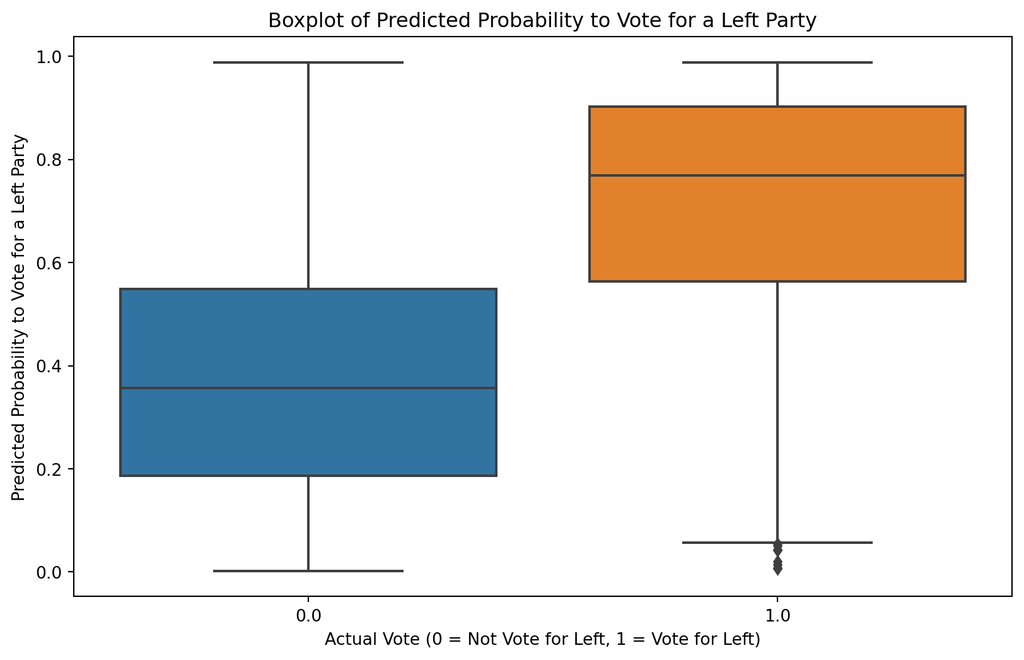

In the boxplot analysis, you can observe the mean values for predicted probabilities that provide insights into the model’s performance and the distribution of predicted probabilities for each category.

We can interpret that a higher mean predicted probability for “Vote for left” aligns with the expectation that individuals with left-leaning political attitudes are more likely to vote for left parties.

In conclusion, the model appears to perform well in predicting voting behavior based on political attitudes. The distinct difference in mean predicted probabilities between the two categories suggests that the model is effective in identifying individuals with a higher likelihood of voting for left parties.

More importantly, it is crucial to look at **the coefficients** from the logistic regression model can provide insights into **the impact of predictor variables** on the likelihood of voting for a left party.

```
  Variable  Coefficient
2  lrscale    -0.960180
4  gincdif    -0.469363
3  wrclmch     0.439674
```

These findings provide valuable insights into the attitudinal factors influencing left-leaning voting decisions, allowing for a distinct understanding of voter behavior. As you can see, there are top-three predictor variables which are `lrscale`, `gincdif`, and `wrclmch` in this model.

- **The positive coefficient** for *climate change concern* aligns with expectations, suggesting that individuals who are more worried about climate change are more likely to vote for a left party.
- **The negative coefficients** for *income difference reduction* and *left-right political scale* indicate that individuals with right-leaning political views and less agreement with government measures to reduce income differences are less likely to vote for a left party.

### 2.5.3 Prediction and Decision Making

#### 2.5.3.1 Predict Left Vote

After predicting left votes in the test sample, comparing actual and predicted labels is crucial. The default threshold of 0.5 can be adjusted using y_pred_threshold90, providing insights into prediction variations based on different probability thresholds.

```
      Actual_Left_Vote  Predicted_Left_Vote_Threshold50  \
5327                 0                                1
7635                 0                                0
2881                 1                                1
8459                 1                                0
2730                 0                                0

      Predicted_Left_Vote_Threshold90
5327                                0
7635                                0
2881                                1
8459                                0
2730                                0
```

**Actual vs. Default Predictions (Threshold 0.5)**

**Actual vs. Conservative Predictions (Threshold 0.9)**

In summary, the default threshold (0.5) might lead to more positive predictions, potentially including false positives. Whereas a higher threshold (0.9) results in more conservative predictions, reducing the number of positive predictions but potentially increasing prediction accuracy.

#### 2.5.3.2 Confusion Matrix

Generating confusion matrices at various probability thresholds can provide more comprehensive assessment of the model’s performance, focusing on optimizing specificity and sensitivity ratio to enhance decision-making for political attitude purposes.

- **Confusion Matrix Criteria:**
  - **True Positive (TP):** Participants correctly predicted as left voters
  - **True Negative (TN):** Participants correctly predicted as non-left voters
  - **False Positive (FP):** Participants incorrectly predicted as left voters (Type I error)
  - **False Negative (FN):** Participants incorrectly predicted as non-left voters (Type II error)
- **In terms of specificity and sensitivity:**
  - **Sensitivity (True Positive Rate or Recall)** is the ability to correctly identify left voters by TP / (TP + FN).
  - **Specificity (True Negative Rate)** is the ability to correctly identify non-left voters by TN / (TN + FP).

```
Confusion Matrix (Threshold 0.1):
          Predicted 0  Predicted 1
Actual 0           59          402
Actual 1            6          640

Confusion Matrix (Threshold 0.25):
          Predicted 0  Predicted 1
Actual 0          161          300
Actual 1           35          611

Confusion Matrix (Threshold 0.5):
          Predicted 0  Predicted 1
Actual 0          326          135
Actual 1          110          536

Confusion Matrix (Threshold 0.75):
          Predicted 0  Predicted 1
Actual 0          424           37
Actual 1          302          344

Confusion Matrix (Threshold 0.9):
          Predicted 0  Predicted 1
Actual 0          456            5
Actual 1          499          147
```

As you can see, the results of the confusion matrices at different probability thresholds offer insights into the model’s performance.

In the context of our advertising campaign aimed at left voters, prioritizing the identification of true left voters is crucial. Therefore, focusing on sensitivity (the ability to correctly identify left voters) becomes the primary goal, while specificity (identifying non-left voters) is a secondary consideration.

At a threshold of 0.1, the model achieves high sensitivity (640 true positives), effectively capturing a substantial number of left-leaning individuals. Although there is a notable false positive rate (402), representing non-left voters, this is deemed acceptable for our campaign objectives. In this scenario, the emphasis is on maximizing the reach to left voters, and a higher false positive rate is a reasonable trade-off.

Therefore, the threshold of 0.1 is suitable for our broad-reaching campaign, aligning with the campaign’s primary goal of targeting and engaging a large number of true left voters, even at the expense of including some non-left individuals.

#### 2.5.3.3 ROC-Curve

Plotting the ROC curve using the actual votes and predicted probabilities for the test sample can visualize the trade-off between specificity and sensitivity. The curve illustrates the true-positive rate (correctly classified left voters) against the false-positive rate (incorrectly classified as left voters among non-left voters).

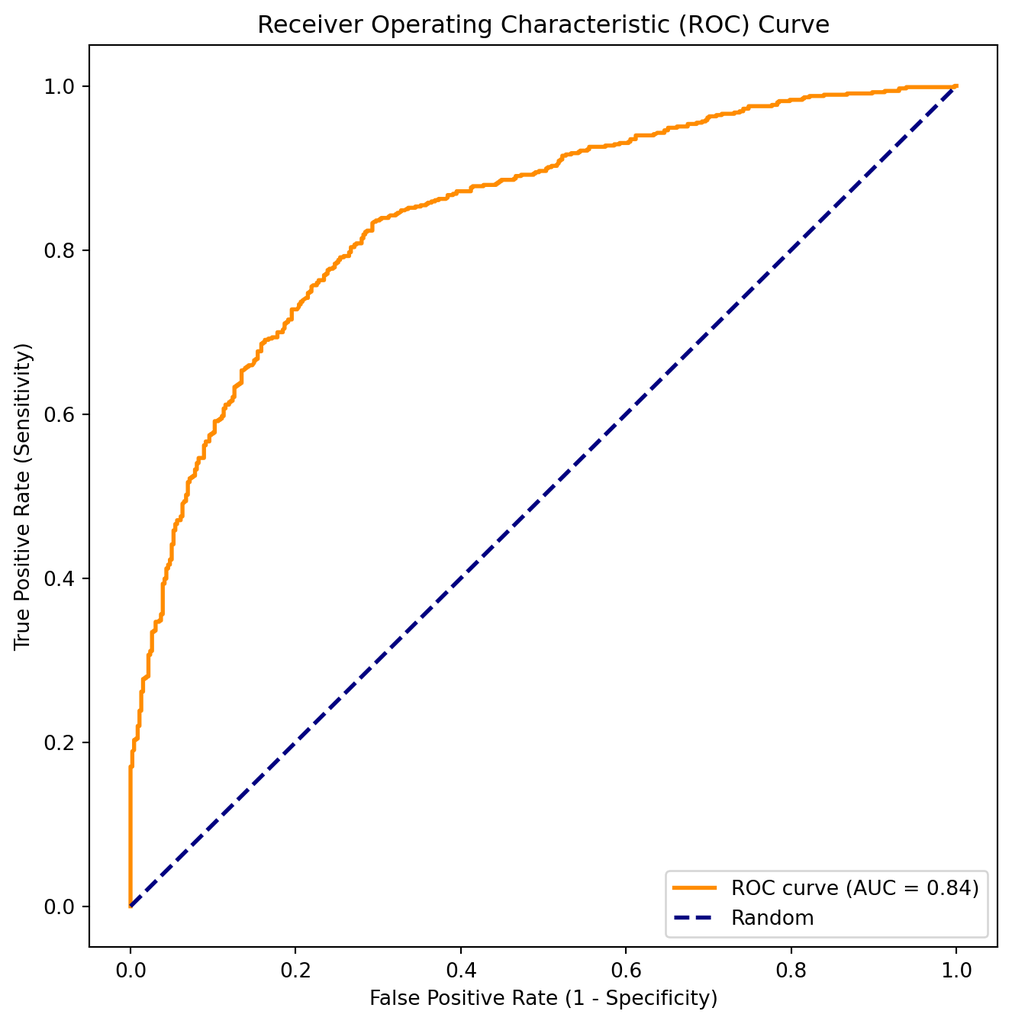

As you can see, the ROC curve is situated above the random line and can be concluded that the model performs better than random chance. The ROC curve suggest that the logistic regression model has good performance in distinguishing between voters and non-voters of the left party.

#### 2.5.3.4 AUC Matrix

```
AUC Score: 0.84
```

The higher the AUC score, the better the model’s ability to correctly classify individuals. In this case, a score of 0.84 indicates that the model has a strong ability to distinguish between the two classes (voting for left or not voting for left).

In summary, A steep ROC curve and a high AUC score of 0.84 suggests that this logistic regression model is performing very well in discriminating between left and non-left voters, making it a reliable tool for predicting political preferences based on the selected features.